# IBD crude incidence calculation

Mohmad A. Mohamad

2023-12-06

**Reference paper**

We tried to simulate the claculation of crude incidence rate for IBD across different ethnic groups from the following paper:

Misra R, Limdi J, Cooney R, Sakuma S, Brookes M, Fogden E, Pattni S, Sharma N, Iqbal T, Munkholm P, Burisch J, Arebi N. Ethnic differences in inflammatory bowel disease: Results from the United Kingdom inception cohort epidemiology study. World J Gastroenterol. 2019 Oct 28;25(40):6145-6157. doi: 10.3748/wjg.v25.i40.6145. PMID: 31686769; PMCID: PMC6824277.

**Statistical methodology in reference paper**

Crude incidence rates were calculated according to the following equation:

Crude incidence rate = No. of cases/ Population at risk

Confidence intervals were calculated assuming a Poisson distribution:

95% CI = Incidence rate ± 1.96 x (Incidence rate / sqrt(Number of cases))

For example, for the crude IBD incidence rate:

Incidence rate = 17.0 per 100,000, Number of cases = 339 Plugging this into the formula: 95% CI = 17.0 ± 1.96 x (17.0 / sqrt(339))

**Our Statistical methodology**

We retrieved IBD No. of cases and total population at risk from the reference population and tried to replicate the calculations using EpiR package

**1. Estimation of crude incidence rates with CI**

```r
# Load required packages
library(epiR)
library(ggplot2)
library(readxl)
library(tidyverse)
library(rstatix)
library(ggpubr)

# Load required data
data <- read_xlsx("IBD.xlsx")

# Make Ethnic groups as factor
data$`Ethnic group` <- factor(data$`Ethnic group`, levels =
                      c("Total population", "White European",
                        "Indian", "Pakistani", "Others"))

# Create a matrix of cases and population at risk
tmp<- as.matrix(cbind(data$Cases,data$`Population at risk`))

# Calculate crude IR, CI
# add calculated column to the data
data <- cbind(data,epi.conf(tmp, ctype = "inc.rate", method = "exact", N = 1000, design = 1, conf.level = 0.95) * 100000)

print(data)
```

```
##       Ethnic group Cases Population at risk       est     lower    upper
## 1   White European   205            1387047 14.779600 12.825550 16.94720
## 2           Indian    68             239814 28.355309 22.019007 35.94711
## 3        Pakistani    24             152264 15.762097 10.099073 23.45275
## 4           Others    37             492461  7.513285  5.290046 10.35607
## 5 Total population   339            2271406 14.924677 13.378036 16.60106
```

**2. Compare incidence rates using pairwise Chi-Square test**

```r
# Add column for control
data <- mutate(data, Control= `Population at risk`-Cases)

# Create contingency table
xtab <- data %>% select(Cases, Control)
dimnames(xtab) <- list(`Ethnic group`= data$`Ethnic group`, IBD= c("Cases", "Control"))

# Pairwise comparisons
prop.test <- pairwise_prop_test(xtab)
print(prop.test)
```

```
## # A tibble: 10 × 5
##    group1         group2                  p    p.adj p.adj.signif
##  * <chr>          <chr>               <dbl>    <dbl> <chr>
##  1 White European Indian           3.26e- 6 2.61e- 5 ****
##  2 White European Pakistani        8.51e- 1 1   e+ 0 ns
##  3 Indian         Pakistani        1.63e- 2 6.52e- 2 ns
##  4 White European Others           1.52e- 4 9.13e- 4 ***
##  5 Indian         Others           5.72e-12 5.72e-11 ****
##  6 Pakistani      Others           6.12e- 3 3.06e- 2 *
##  7 White European Total population 9.47e- 1 1   e+ 0 ns
##  8 Indian         Total population 1.37e- 6 1.23e- 5 ****
##  9 Pakistani      Total population 8.8 e- 1 1   e+ 0 ns
## 10 Others         Total population 7.03e- 5 4.92e- 4 ***
```

**3. Make bar chart**

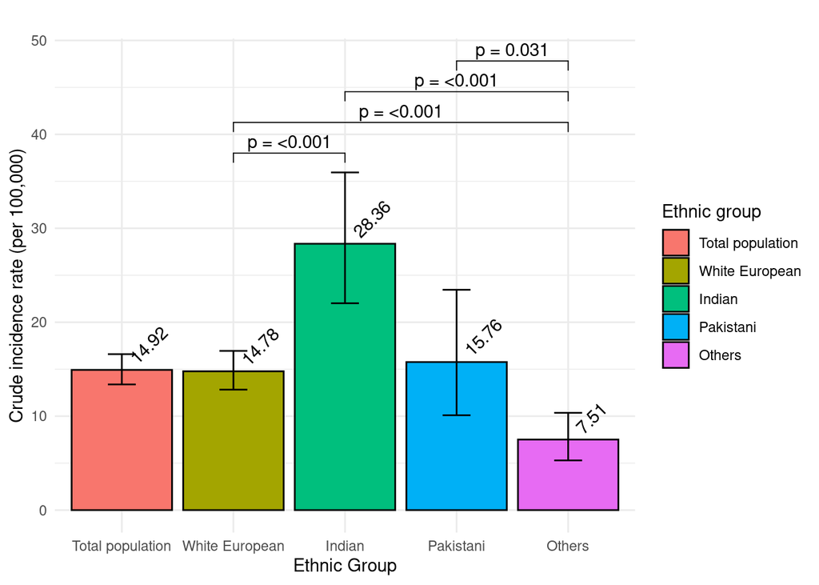

Crude incidence rates across different ethnic groups

```r
# add a column with Ethnic group labels
prop.test <- prop.test %>% mutate(`Ethnic group`= group1)

# Exclude total population from the comparsion
prop.test.short <- prop.test %>% filter(group1 !=" Total population") %>%
  filter(group2 != "Total population")

# Make a bar chart
ggplot(data, aes(x = `Ethnic group`, y = est, fill=`Ethnic group`)) +
  geom_bar(stat = "identity", position = "dodge", color = "black") +
  geom_errorbar(aes(ymin = lower, ymax = upper), position = position_dodge(0.9), width = 0.25) +
  labs(title = "",
       x = "Ethnic Group",
       y = "Crude incidence rate (per 100,000)") +
  geom_text(aes(label = round(est, digits=2)), nudge_y = 1, nudge_x=0.1, hjust="left", angle=45 ) +
theme_minimal() +

# add p values
  stat_pvalue_manual(prop.test.short, label="p = {scales::pvalue(p.adj)}",
  y.position = 38, step.increase = 0.1 , hide.ns = TRUE)
```